# Central Limit Theorem

Arnab Aich

## Introduction

Statistics help us make sense of data. One of the key concepts in statistics is the Central Limit Theorem (CLT). It tells us that no matter what the original population looks like, the average (mean) of multiple samples will tend to follow a normal (bell-shaped) distribution as the number of samples increases. This is crucial because it allows us to make predictions and conclusions about data in a predictable way.

## Simple Random Sampling

Simple random sampling is a sampling technique where each unit in the population has equal chance to appear in the sample. It’s fundamental for ensuring that our samples are unbiased reflections of the entire population.

Simple random sampling is important because it ensures that the assumptions underlying the Central Limit Theorem hold true. This means the results of our sample analysis are more likely to be accurate and representative of the entire population.

### Example

Imagine we randomly select 30 students from a school of 300 for a survey on lunch preferences. Each student, whether in the 1st grade or the 12th grade, has an equal chance of being selected.

### Importance of Large Sample Sizes

Large sample sizes are crucial because they reduce the variability in estimates, leading to more reliable results. For instance, in political polling, a larger sample size can provide a more accurate reflection of the voting population’s preferences. The rule of thumb for the minimum sample size needed to approximate the distribution of the sample mean by a normal distribution depends on the shape of the population distribution:

- For **symmetric** and **bell-shaped** distributions, there is no required sample size.
- For **symmetric** distributions(not bell), a sample size of $15$ is often sufficient.
- For **skewed distributions**, larger sample sizes may be needed. Generally, a sample size of $30$ or more is recommended.
- For **highly skewed** or **heavy-tailed** distributions, sample sizes significantly larger than $50$ may be necessary to ensure the normal approximation is adequate.

## Central Limit Theorem

The Central Limit Theorem (CLT) is one of the most powerful and well-known results in all of statistics. It states that the distribution of sample means approximates a normal distribution as the sample size becomes large, regardless of the population’s distribution, provided the population has a finite variance.

**Derivation of the Central Limit Theorem**

Let $X_1, X_2, ..., X_n$ be a random sample of size $n$ drawn from a population with mean $\mu$ and variance $\sigma^2$. The sample mean $\bar{X}$ can be expressed as:

$$\bar{X} = \frac{1}{n} \sum_{i=1}^n X_i$$

By the properties of expectation and variance, we have:

$$E(\bar{X}) = \mu
\;\;\;\; , \;\;\;\;
Var(\bar{X}) = \frac{\sigma^2}{n}$$

According to the Central Limit Theorem, as $n$ approaches infinity, the distribution of the standardized sample means:

$$Z = \frac{\bar{X} - \mu}{\sigma / \sqrt{n}} \to \text{Normal}(0,1)$$

approaches a standard normal distribution. The term $\frac{\sigma}{\sqrt{n}}$ is known as **standard error** of sample mean.

## Value to Probability Problems

Using the Central Limit Theorem, we can solve problems where we know the value and need to find the corresponding probability. Let’s consider the context of test scores in a school. Suppose test scores are distributed with a mean of 500 and a standard deviation of 100.

### Left-tailed problem

What is the probability that the average test score from a random sample of 40 students is less than 485?

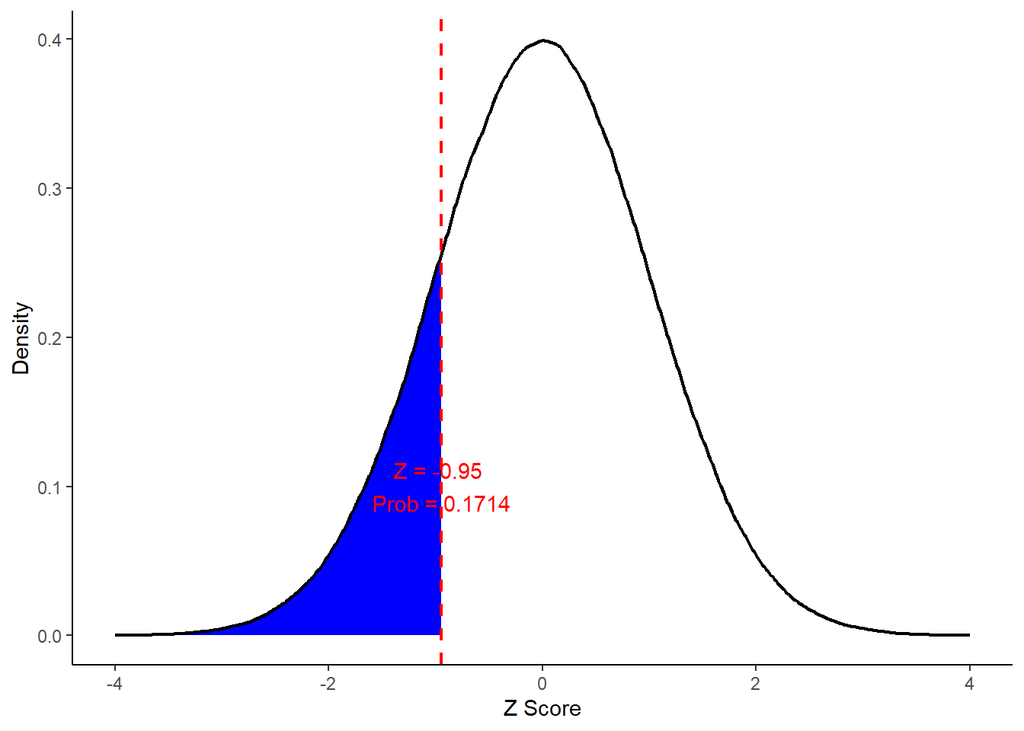

### Right-tailed problem

What is the probability that the average test score is greater than 520?

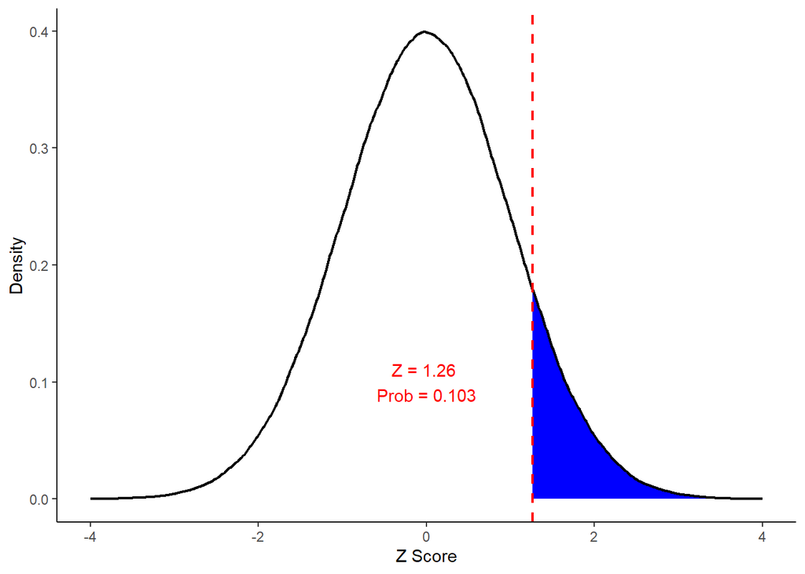

### Both-tailed problem

What is the probability that the average falls between 490 and 510?

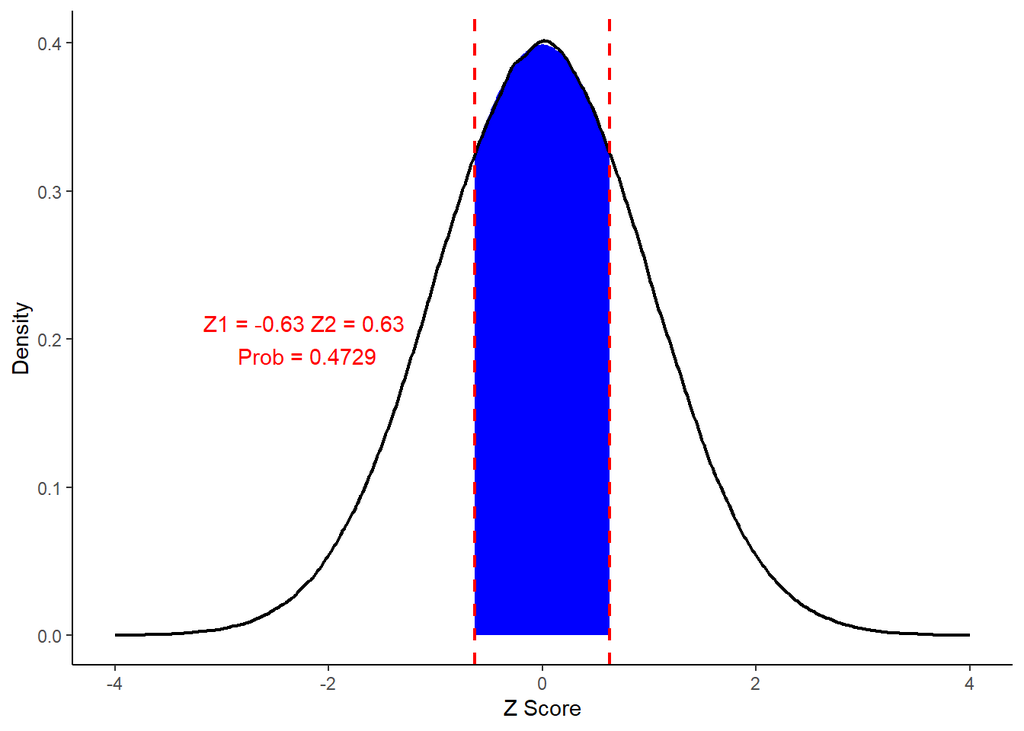

## Probability to Value Problems

Using the Central Limit Theorem, we can solve problems where we know the probability and need to find the corresponding value. Let’s consider the context of daily sales at a retail store. Suppose sales are distributed with a mean of $3000$ and a standard deviation of $500$. We’ll find specific sales values corresponding to certain probabilities based on a sample of size 30.

### Left-tailed problem

Find the sales amount below which the bottom 10% of days fall.

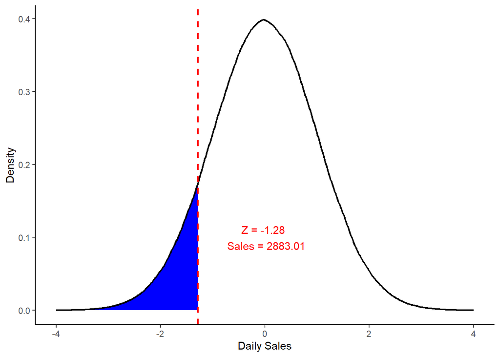

**Calculations**

### Right-tailed problem

Find the sales amount above which the top 5% of days fall.

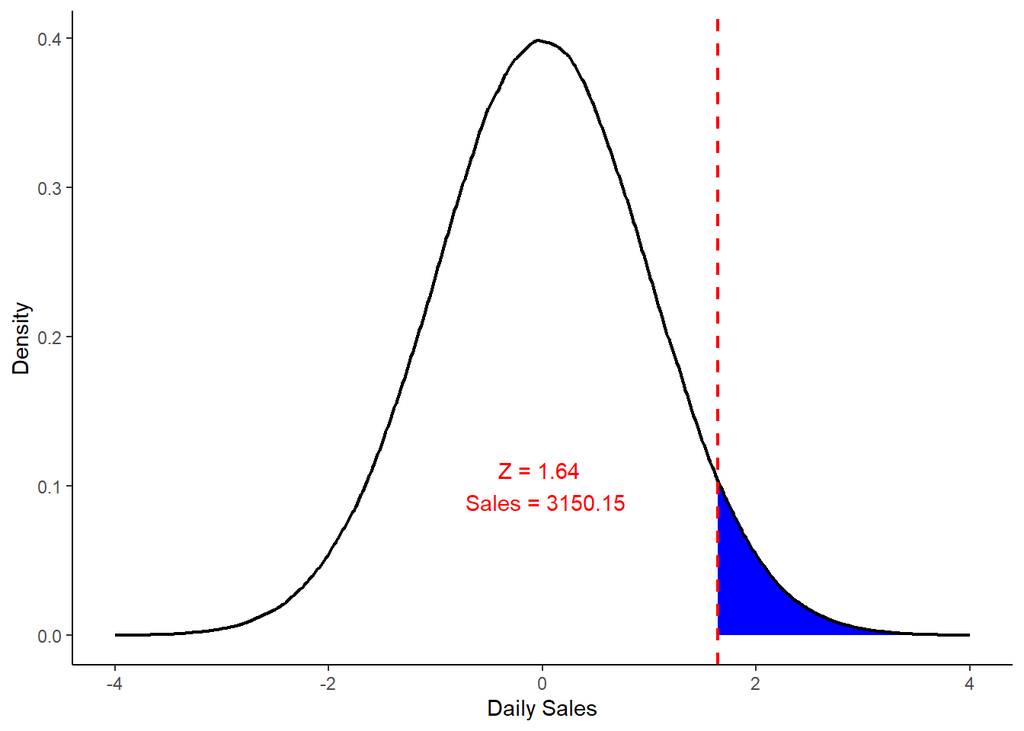

**Calculation**

### Both-tailed problem

Find the range sales amount containing the middle 75% of days.

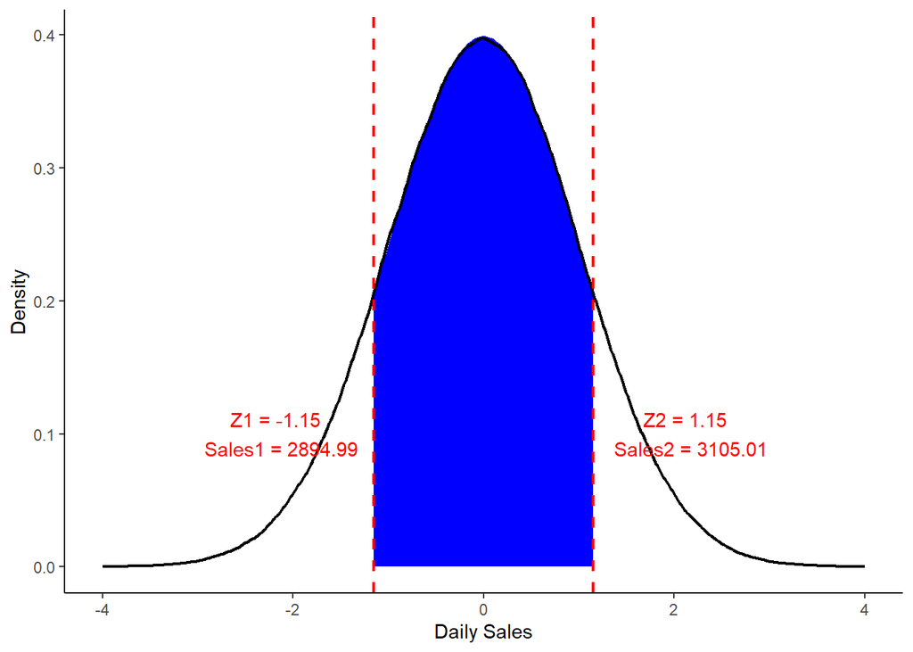

## Recap

Throughout this document, we have explored the powerful Central Limit Theorem (CLT) and its practical applications in solving real-world problems. We’ve seen how the CLT helps in understanding the distribution of sample means and allows for the approximation of probabilities in normally distributed populations, regardless of the population’s original distribution. The key takeaways include:

- **Understanding Sampling**: Emphasized the importance of simple random sampling to ensure unbiased samples that reflect the entire population.
- **Applications of CLT**: Demonstrated through examples in daily sales and test scores, showing how to convert both values to probabilities and probabilities to values.
- **Statistical Accuracy**: Discussed the importance of large sample sizes in achieving more accurate and reliable statistical results.

## Questions and Answers

#### **What is the Central Limit Theorem?**

The CLT states that the distribution of sample means approximates a normal distribution as the sample size becomes large, regardless of the population’s distribution.

#### **Why is simple random sampling important in statistics?**

It ensures each member of the population has an equal chance of being selected, leading to unbiased and representative samples.

#### **How does sample size affect the application of the CLT?**

Larger sample sizes reduce the standard error and make the approximation to the normal distribution more accurate.

#### **Can you apply the CLT to any population distribution?**

Yes, the CLT can be applied as long as the population has a finite variance, though the shape of the population distribution affects the minimum sample size needed.

#### **How do you calculate the Z-score in CLT applications?**

The Z-score is calculated as $Z = \frac{\bar{X} - \mu}{\sigma / \sqrt{n}}$, where $\bar{X}$ is the sample mean.

#### **What does the standard error of the mean tell us?**

It measures the dispersion of sample means around the population mean and decreases with increasing sample size.

#### **What is the role of the standard deviation in the CLT?**

The standard deviation of the population, scaled by the square root of the sample size, determines the spread of the sample means around the population mean.

#### **How does the CLT help in solving probability problems?**

The CLT allows us to approximate probabilities in normally distributed populations, making it easier to solve problems involving sample means and probabilities.